# Demographic Analysis with DemogAnr

## Why this package

Applied demographic work is still carried out largely in spreadsheets: a life table here, a total fertility rate there, an age distribution split into single years. Spreadsheets are visual and familiar, but their formulas are invisible until each cell is inspected, and reproducing an analysis a year later often means rebuilding it from memory.

Wherever possible, the examples below reproduce a published worked example, so that you can follow the calculation in the textbook alongside the code.

## Data bundled with the package

| Data set | Contents |
| --- | --- |
| `gphc2010` | Population and deaths by age, 2010 Ghana Population and Housing Census |
| `ghmort2021` | Population and deaths by age and sex, Ghana 2021 |
| `ghpop2021` | Single-year age distribution by sex, Ghana 2021 |
| `region2000` | Regional base-year parameters, Ghana 2000 |
| `standards` | Brass African and General-UN standard life tables |
| `data` | A grouped (five-year) age distribution |

## 1. Rates: fertility and mortality

`dem.fert()` computes the crude birth rate, general fertility rate, age-specific rates and the total fertility rate. Here is the Bangladesh 1974 schedule from United Nations *Manual X*, Chapter II, whose reported total fertility rate is 4.83.

```r
bangladesh <- data.frame(
  age         = c("15-19","20-24","25-29","30-34","35-39","40-44","45-49"),
  women       = c(3014706, 2653155, 2607009, 2015663, 1771680, 1479505, 1135129),
  live_births = c(320406, 609269, 561494, 367833, 237297, 95357, 38125),
  population  = 71315944
)
fert <- dem.fert(bangladesh, type = "all", age_col = "age",
                 population_col = "population", women_col = "women",
                 births_col = "live_births", graph = FALSE)
fert$results$TFR
```

```
#> [1] 4.828819
```

`dem.cdr()` does the same for mortality. Preston et al. (2001, Box 1.2) report a crude death rate of 11.47 per 1000 for Sweden in 1988:

```r
sweden88 <- data.frame(population = 8438477, deaths = 96756)
dem.cdr(sweden88, type = "CDR", population_col = "population",
        deaths_col = "deaths", graph = FALSE)$results$CDR
```

```
#> [1] 11.46605
```

Childhood and maternal mortality are available through `dm.chm()` and `dem.mmr()`.

## 2. Life tables

`lifetable()` builds a complete or abridged life table from death rates, or from deaths and population. Interval widths are taken from the age vector, and the separation factors ${}_na_x$ follow Coale–Demeny by default.

```r
lt <- lifetable(gphc2010, age = "Age", pop = "Pop", Dx = "Deaths",
                graph = FALSE)
head(lt$lifetable)
```

```
#>   Age n  nDx          nMx       nax         nqx        lx       dx        Lx      Tx
#> 1   0 1 5757 0.0079153496 0.0662448 0.007857276 100000.00 785.7276  99266.32 7542111
#> 2   1 4 4960 0.0016326805 1.6287104 0.006505535  99214.27 645.4420 395326.56 7442844
#> 3   5 5 2363 0.0006322043 2.5000000 0.003156033  98568.83 311.0865 492066.44 7047518
#> 4  10 5 1879 0.0005603806 2.5000000 0.002797983  98257.74 274.9235 490601.41 6555451
#> 5  15 5 2820 0.0009721694 2.5000000 0.004849062  97982.82 475.1247 488726.29 6064850
#> 6  20 5 3776 0.0013759704 2.5000000 0.006856267  97507.70 668.5388 485867.13 5576124
#>         ex
#> 1 75.42111
#> 2 75.01788
#> 3 71.49844
#> 4 66.71689
#> 5 61.89708
#> 6 57.18650
```

```r
lt$metrics$LifeExpectancyAtBirth
```

```
#> [1] 75.42111
```

Passing `nax_method = "keyfitz"` refines the adult separation factors iteratively; passing a `nax` vector borrows them from any external model life table. `lifetable_nqx()` builds a table directly from a series of ${}_nq_x$.

## 3. Multiple decrement and cause-deleted tables

When deaths are classified by cause, `multiple_decrement()` distributes the life-table deaths across causes. This reproduces Preston et al. (2001) Box 4.1 for US females in 1991: of 100,000 newborns, 21,205 (21.2%) would eventually die of neoplasms.

```r
us91 <- data.frame(
  Age  = c(0, 1, seq(5, 85, 5)),
  Dall = c(15758, 3169, 1634, 1573, 3955, 4948, 6491, 9428, 12027, 15543,
           19264, 25384, 37211, 59431, 88087, 114693, 143554, 164986, 320578),
  Dneo = c(63, 275, 268, 217, 318, 467, 856, 1924, 3532, 5958,
           8434, 11673, 17078, 25263, 33534, 36695, 36571, 30220, 32739),
  lx   = c(100000, 99217, 99050, 98959, 98870, 98637, 98379, 98070, 97653,
           97083, 96289, 95008, 93018, 89882, 85249, 78711, 69618, 57486, 41756),
  nqx  = c(0.00783, 0.00168, 0.00092, 0.00090, 0.00236, 0.00262, 0.00314,
           0.00425, 0.00584, 0.00818, 0.01330, 0.02095, 0.03371, 0.05155,
           0.07669, 0.11552, 0.17427, 0.27363, 1.00000),
  nax  = c(0.152, 1.605, 2.275, 2.843, 2.657, 2.547, 2.550, 2.616, 2.677,
           2.685, 2.681, 2.655, 2.647, 2.646, 2.631, 2.628, 2.618, 2.570, 6.539)
)
us91$Dother <- us91$Dall - us91$Dneo

md <- multiple_decrement(us91, age = "Age", causes = c("Dneo", "Dother"),
                         deaths = "Dall", lx = "lx", nqx = "nqx", graph = FALSE)
round(md$cause_distribution, 3)
```

```
#>   Dneo Dother
#>  0.212  0.788
```

`cause_deleted_lt()` answers the companion question: what would life expectancy be if the cause were eliminated? The deletion assumption is yours to choose through `method`.

```r
cd <- cause_deleted_lt(us91, age = "Age", cause = "Dneo", deaths = "Dall",
                       lx = "lx", nqx = "nqx", nax_all = "nax", graph = FALSE)
c(e0 = cd$e0, without_neoplasms = cd$e0_deleted, gain = cd$gain)
```

```
#>                e0 without_neoplasms              gain
#>         78.920244         82.431586          3.511342
```

Both functions accept either a population column, from which the life table is built, or a ready-made table through `lx`, `nqx` and `nax_all`.

## 4. Reproduction and the stable population

`reproduction()` computes the gross and net reproduction rates. For US females in 1991 (Preston et al. 2001, Box 5.5) the published values are GRR 1.013 and NRR 0.995.

```r
us1991 <- data.frame(
  age   = seq(10, 45, 5),
  fbir  = c(5816, 253979, 532712, 596823, 431694, 162005, 25531, 829),
  women = c(8620, 8371, 9419, 10325, 11125, 10344, 9496, 7188) * 1000,
  nLx   = c(494603, 493804, 492552, 491138, 489356, 486941, 483577, 478475)
)
r <- reproduction(us1991, age = "age", births = "fbir", women = "women",
                  nLx = "nLx", radix = 1e5, fraction_female = 1, graph = FALSE)
c(GRR = r$GRR, NRR = r$NRR)
```

```
#>       GRR       NRR
#> 1.0132277 0.9953345
```

`stable_population()` solves Lotka’s equation for the intrinsic growth rate by Coale’s iterative procedure. Preston et al. (2001, Box 7.1) obtain $r = 0.01424$ for Egypt in 1997:

```r
egypt <- data.frame(
  age = seq(15, 45, 5),
  Lx  = c(4.66740, 4.63097, 4.58518, 4.53206, 4.46912, 4.39135, 4.28969),
  ma  = c(0.00567, 0.06627, 0.11204, 0.07889, 0.05075, 0.01590, 0.00610)
)
sp <- stable_population(egypt, age = "age", asfr = "ma", nLx = "Lx",
                        radix = 1, fraction_female = 1, graph = FALSE)
c(r = sp$r, b = sp$b, d = sp$d, NRR = sp$NRR)
```

```
#>          r          b          d        NRR
#> 0.01424406 0.04963294 0.03538888 1.52741373
```

## 5. Indirect estimation

Where registration is incomplete, fertility and child mortality are estimated indirectly. `pf_ratio()` implements the Brass P/F ratio method; on the *Manual X* Bangladesh 1974 example the adjustment factor is 1.500 and the adjusted total fertility rate 7.24.

```r
bd <- data.frame(
  age    = seq(15, 45, 5),
  women  = c(3014706, 2653155, 2607009, 2015663, 1771680, 1479505, 1135129),
  ceb    = c(1160919, 4901382, 9085852, 9910256, 10384001, 9164329, 6905673),
  births = c(320406, 609269, 561494, 367833, 237297, 95357, 38125)
)
pf <- pf_ratio(bd, age = "age", women = "women", ceb = "ceb",
               births = "births", graph = FALSE)
c(K = pf$K, TFR = pf$TFR, TFR_adjusted = pf$TFR_adjusted)
```

```
#>            K          TFR TFR_adjusted
#>     1.499137     4.828819     7.239061
```

`chm_brass()` estimates child mortality from children ever born and children surviving, by the Brass-Trussell method. It returns $q(x)$ with the calendar date each estimate refers to.

```r
panama <- data.frame(
  women = c(2695, 2095, 1828, 1605, 1362, 1128, 930),
  ceb   = c(557, 2633, 4757, 6085, 6722, 6367, 5276),
  cd    = c(40, 130, 312, 435, 636, 686, 689)
)
est <- chm_brass(panama, women_col = "women", ceb_col = "ceb",
                 cd_col = "cd", model = "west", survey_year = 1976.7)
est$qx[est$x == 5]
```

```
#> [1] 0.0717859
```

On its own that is a set of probabilities, not a life table. `model_lifetable()` finishes the job: give it the estimated $q(5)$ and it returns the model table matching it, in any of the four Coale-Demeny families or the five United Nations patterns.

```r
fitted <- model_lifetable("west", sex = "male", q5 = est$qx[est$x == 5],
                          graph = FALSE)
fitted$metrics$LifeExpectancyAtBirth
```

```
#> [1] 62.85683
```

The same child mortality implies different adult mortality in different families, which is why the family has to be chosen rather than assumed:

```r
sapply(c("CD_West", "CD_North", "CD_South", "CD_East"), function(f)
  model_lifetable(f, sex = "male", q5 = est$qx[est$x == 5],
                  graph = FALSE)$metrics$LifeExpectancyAtBirth)
```

```
#>  CD_West CD_North CD_South  CD_East
#> 62.85683 63.79673 67.77688 63.77914
```

The alternative to picking a family is the Brass relational logit model, which fits a two-parameter transformation of a standard rather than choosing from a grid. `brass_logit()` estimates the level $\alpha$ and the age-pattern slope $\beta$; `complete = TRUE` carries them through to the life table they imply.

```r
fit <- brass_logit(data.frame(age = est$x, qx = est$qx),
                   qx_col = "qx", age_col = "age", standard = "African",
                   complete = TRUE)
round(fit$coefficients, 4)
```

```
#>     (Intercept) standard_logits
#>         -0.7556          0.6685
```

```r
fit$lifetable$metrics$LifeExpectancyAtBirth
```

```
#> [1] 68.5678
```

`brass_lifetable()` can also be used on its own, with no data at all: give it $\alpha$ and $\beta$ directly, or a target level to solve for.

```r
brass_lifetable(target_e0 = 60, standard = "African",
                graph = FALSE)$brass$alpha
```

```
#> [1] -0.5356655
```

Adult mortality is estimated the same way round. Where `chm_brass()` uses a mother’s report on her children, `orphanhood()` uses children’s reports on their mother, and returns female survivorship from age 25 with the number of years before the survey each estimate refers to. On the *Manual X* Bolivia 1975 example:

```r
bolivia <- data.frame(
  age   = seq(15, 50, 5),
  alive = c(5540, 3995, 2886, 1910, 1272, 855, 541, 234),
  dead  = c(448, 541, 769, 852, 945, 1059, 985, 788),
  s10   = c(NA, 0.9060, 0.8401, 0.7474, 0.6313, 0.5175, 0.3996, NA)
)
orph <- orphanhood(bolivia, age = "age", alive = "alive", dead = "dead",
                   prop10 = "s10", M = 28.8, survey_year = 1975.5,
                   graph = FALSE)
orph$table[, c("age", "W", "lx_ratio", "t", "ref_date")]
```

```
#>   age      W  lx_ratio        t ref_date
#> 1  20 0.9874 0.9246236  8.59762 1966.902
#> 2  25 1.0976 0.8896261 10.28165 1965.218
#> 3  30 1.1784 0.8070999 11.78853 1963.711
#> 4  35 1.2416 0.7199834 13.17346 1962.327
#> 5  40 1.2414 0.6044157 14.25640 1961.244
#> 6  45 1.2126 0.4663074 15.02985 1960.470
#> 7  50 1.0540 0.3613018       NA       NA
```

Because each age group of respondents looks a different distance into the past, one survey yields a series of estimates spread over roughly 8 to 15 years, which is what makes the method useful for a trend rather than a level.

## 6. Completeness of death registration

A life table built from registered deaths is only as good as the registration. Where it is incomplete – the normal case wherever civil registration is still developing – the table understates mortality, and the first task is to find out by how much. The death distribution methods do that from two censuses and the deaths recorded between them.

```r
d <- data.frame(
  age = c(0, seq(5, 85, 5)),
  n1  = c(41255, 36289, 31948, 28121, 24743, 21758, 19116, 16770, 14677,
          12798, 11094, 9527, 8060, 6659, 5298, 3970, 2706, 2614),
  n2  = c(52973, 46596, 41022, 36108, 31770, 27938, 24545, 21533, 18846,
          16433, 14245, 12233, 10349, 8550, 6802, 5098, 3475, 3356),
  dth = c(516, 134, 126, 123, 126, 136, 154, 184, 229, 294, 385, 508,
          668, 865, 1084, 1282, 1380, 2833)
)
g <- ggb(d, age = "age", pop1 = "n1", pop2 = "n2", deaths = "dth",
         t1 = 2000, t2 = 2010, graph = FALSE)
c(completeness = g$completeness, coverage_ratio = g$coverage_ratio)
```

```
#>   completeness coverage_ratio
#>      0.6995644      1.0009353
```

These deaths were registered at 70 per cent completeness, and the generalized growth balance recovers it. `seg()` estimates the same quantity by synthetic extinct generations, and `ggb_seg()` runs the two in sequence, using the first to correct for the censuses covering the population differently before the second is applied.

```r
c(GGB = g$completeness,
  SEG = seg(d, "age", "n1", "n2", "dth", 2000, 2010, graph = FALSE)$completeness,
  combined = ggb_seg(d, "age", "n1", "n2", "dth", 2000, 2010,
                     graph = FALSE)$completeness)
```

```
#>       GGB       SEG  combined
#> 0.6995644 0.7014690 0.7044130
```

Neither method should be used without looking at its diagnostic plot first: `plot()` on a `ggb()` result shows the fitted line, which should be straight, and on a `seg()` result the age-specific ratios, which should be flat. A curve in either is a sign that the assumptions – a closed population, registration equally complete at every age – do not hold.

## 7. Standardization and decomposition

Crude rates are not comparable across populations with different age structures. `standardize()` compares two populations against a common standard, and `decompose_rates()` splits the difference into a rate component and an age-composition component.

```r
male   <- subset(ghmort2021, Sex == "Male")
female <- subset(ghmort2021, Sex == "Female")
comp <- data.frame(
  age  = male$Age,
  m_m  = male$Deaths / male$Population,
  m_f  = female$Deaths / female$Population,
  n_m  = male$Population,
  n_f  = female$Population
)
standardize(comp, "age", rate1_col = "m_m", rate2_col = "m_f",
            pop1_col = "n_m", pop2_col = "n_f",
            labels = c("Males", "Females"))
```

```
#> Age standardization: Males (1) vs Females (2)
#> Standard age distribution: average
#>
#>  age     C1     C2   Cstd    M1    M2 M1Cstd M2Cstd
#>    0 0.0243 0.0231 0.0237 0.042 0.036 0.9955 0.8533
#>    1 0.1015 0.0961 0.0988 0.006 0.005 0.5930 0.4941
#>    5 0.1253 0.1177 0.1215 0.002 0.002 0.2430 0.2430
#>   10 0.1127 0.1061 0.1094 0.001 0.001 0.1094 0.1094
#>   15 0.1088 0.1061 0.1074 0.002 0.001 0.2148 0.1074
#>   20 0.0949 0.0961 0.0955 0.003 0.002 0.2865 0.1910
#>   25 0.0830 0.0871 0.0851 0.004 0.003 0.3403 0.2553
#>   30 0.0765 0.0783 0.0774 0.005 0.004 0.3869 0.3095
#>   35 0.0658 0.0668 0.0663 0.006 0.005 0.3977 0.3314
#>   40 0.0528 0.0514 0.0521 0.008 0.006 0.4167 0.3126
#>   45 0.0419 0.0403 0.0411 0.010 0.008 0.4112 0.3289
#>   50 0.0322 0.0334 0.0328 0.014 0.011 0.4592 0.3608
#>   55 0.0236 0.0252 0.0244 0.020 0.015 0.4880 0.3660
#>   60 0.0204 0.0229 0.0217 0.029 0.022 0.6288 0.4771
#>   65 0.0135 0.0149 0.0142 0.043 0.034 0.6101 0.4824
#>   70 0.0098 0.0118 0.0108 0.065 0.053 0.7032 0.5733
#>   75 0.0057 0.0081 0.0069 0.098 0.081 0.6758 0.5586
#>   80 0.0072 0.0145 0.0109 0.155 0.135 1.6890 1.4711
#>
#>   Crude rate:            (1) 8.86   (2) 8.49   per 1000
#>   Age-standardized rate: (1) 9.65   (2) 7.83   per 1000
#>   Ratio of standardized rates (1/2): 1.233
#>   Comparative mortality ratio (CMR, 1 vs 2): 1.238
```

`decompose_LE()` attributes a difference in life expectancy at birth to each age group, following Arriaga.

## 8. Projection

`math_project()` performs deterministic subnational projection by six methods (linear, exponential, geometric, constant-share, shift-share, share-of-growth), optionally constraining units to a parent control total.

`cohort_component()` performs the full age–sex projection through a Leslie matrix. It reproduces Preston et al. (2001) Box 6.1 for Swedish females exactly:

```r
sweden <- data.frame(
  Age = c(seq(0, 80, 5), 85),
  N93 = c(293395, 248369, 240012, 261346, 285209, 314388, 281290, 286923,
          304108, 324946, 247613, 211351, 215140, 221764, 223506, 183654,
          141990, 112424),
  Lx  = c(497487, 497138, 496901, 496531, 495902, 495168, 494213, 492760,
          490447, 486613, 480665, 471786, 457852, 436153, 402775, 350358,
          271512, 291707),
  Fx  = c(0, 0, 0, 0.0120, 0.0908, 0.1499, 0.1125, 0.0441, 0.0074, 0.0003,
          rep(0, 8))
)
cc <- cohort_component(sweden, age = "Age", population = "N93", nLx = "Lx",
                       asfr = "Fx", steps = 2, graph = FALSE)
round(cc$totals)
```

```
#>      y0      y5     y10
#> 4397428 4449570 4478712
```

`project_population()` carries uncertainty through the demographic balancing equation $g = b - d + m$, drawing each component from a distribution that you specify.

```r
pp <- project_population(region2000[1:4, ],
        base_year = 2000, future_year = 2010,
        region_var = "Country", subregion_var = "Region",
        base_pop_var = "base_pop", birth_rate_var = "cbr",
        death_rate_var = "cdr", net_migration_var = "nmr",
        num_samples = 500, graph = FALSE)
subset(pp, year == 2010)
```

```
#>    region     subregion year   lower  median    mean   upper
#> 11  Ghana       Western 2010 1790114 1866938 1867967 1957554
#> 22  Ghana       Central 2010 1826615 1911712 1912354 2002872
#> 33  Ghana Greater Accra 2010 3779998 3930477 3935194 4087288
#> 44  Ghana         Volta 2010 1240419 1297273 1298658 1358384
```

Each trajectory draws its rates once and holds them across the horizon, so the band widens with the projection. Supplying `death_dist`, `birth_dist` or `migration_dist` replaces the defaults with your own sampler.

`project_population()` can also carry an assumed trend rather than holding each rate constant. `birth_target`, `death_target` and `migration_target` give the value a component is heading towards by `future_year` (a single number, or a column of per-region targets), and `path` chooses whether it gets there `"linear"`ly or `"exponential"`ly. Each trajectory then draws both a start rate and an end rate and interpolates between them, so the trend and the uncertainty about it travel together; `target_cv` sets the spread around the target and is normally wider than `cv`, since a rate two decades out is less certain than today’s:

```r
pp_trend <- project_population(region2000[1:4, ],
        base_year = 2000, future_year = 2030,
        region_var = "Country", subregion_var = "Region",
        base_pop_var = "base_pop", birth_rate_var = "cbr",
        death_rate_var = "cdr", net_migration_var = "nmr",
        birth_target = 0.024, death_target = 0.008,
        cv = 0.05, target_cv = 0.20,
        num_samples = 500, graph = FALSE)
subset(pp_trend, year == 2030)
```

```
#>     region     subregion year   lower  median    mean   upper
#> 31   Ghana       Western 2030 2581116 2853365 2876062 3207361
#> 62   Ghana       Central 2030 2238803 2491521 2508962 2776886
#> 93   Ghana Greater Accra 2030 6216186 6801402 6868495 7610837
#> 124  Ghana         Volta 2030 1386091 1532897 1540571 1712578
```

Omitting the targets holds every rate at its base-year value and reproduces the earlier, constant-rate behaviour exactly.

`calibrate_regions()` addresses a different problem: not projecting each region, but disaggregating a **national projection that is already settled** down to regions, raking the regions back onto the national control total in every year. Where `project_population()` lets each region find its own total, `calibrate_regions()` takes the national trajectory as given and asks only how it is shared out, which is the sequence used in official projection work (first agree the national numbers, then split them regionally):

```r
base_total <- sum(region2000$base_pop)
national <- data.frame(
  year  = seq(2000, 2020, 5),
  total = round(base_total * exp(0.025 * seq(0, 20, 5)))
)
cal <- calibrate_regions(region2000,
        region_col = "Region", pop_col = "base_pop",
        national = national, year_col = "year", total_col = "total",
        deviation = 0.08, num_samples = 500, graph = FALSE)
cal$check
```

```
#>   year regional_sum  control difference
#> 1 2000     18912079 18912079          0
#> 2 2005     21430193 21430193          0
#> 3 2010     24283590 24283590          0
#> 4 2015     27516913 27516913          0
#> 5 2020     31180747 31180747          0
```

Each region is allowed to deviate from the national profile by a mean-preserving lognormal (here with coefficient of variation 0.08), phased in over the horizon, and then raked back onto the national total; `cal$check` confirms the regional sum reproduces the control total in every year. With no `deviation` the function reduces to the ordinary constant-share allocation and every raking factor is 1.

## 9. Data quality, smoothing and graduation

Reported ages should be screened before analysis. `whipple()` and `myers()` measure digit preference, and `un_age_sex_accuracy()` combines age and sex ratios into the United Nations joint index.

```r
males <- subset(ghpop2021, Sex == "Male")
w <- whipple(males, age_col = "Age", pop_col = "Population", graph = FALSE)
w$index
```

```
#> [1] 115.2924
```

Where screening shows misreporting, the age distribution can be smoothed. The decision is not automatic. Smoothing assumes that people were reported at the wrong age rather than missed, so the deficit in an under-enumerated age group is spread to its neighbours; and genuine irregularities in the age structure are erased together with the errors.

The 1960 census of Ghana, the example Kpedekpo (1982) uses for the United Nations index, shows the saw-tooth pattern of age misreporting. The female age ratios fall to 84 and 82 at 10-14 and 15-19 and rise to 113 and 108 at 20-24 and 25-29: an excess of women at 20-29 at the expense of 10-19. `smooth_ages()` applies the five formulas of the Census Bureau’s AGESMTH workbook. Carrier-Farrag, Karup-King-Newton and Arriaga only redistribute people between the two halves of each ten-year group, so they cannot repair a transfer between ten-year groups; the United Nations formula and Arriaga’s strong smoothing reach across them. The age ratio score, the mean absolute deviation of the age ratios from 100, falls accordingly:

```r
ghana1960 <- data.frame(
  age = c("0-4","5-9","10-14","15-19","20-24","25-29","30-34","35-39",
          "40-44","45-49","50-54","55-59","60-64","65+"),
  females = c(654258, 503070, 323460, 265534, 322576, 306329, 245883,
              179182, 145572, 95590, 81715, 48412, 54572, 100392)
)
methods <- c("carrier_farrag", "kkn", "arriaga", "united_nations", "strong")
scores <- sapply(methods, function(m) {
  smooth_ages(ghana1960, "age", "females", method = m,
              graph = FALSE)$score_smoothed
})
reported <- smooth_ages(ghana1960, "age", "females",
                        graph = FALSE)$score_reported
round(c(reported = reported, scores), 2)
```

```
#>       reported carrier_farrag            kkn        arriaga united_nations         strong
#>          11.92           9.95          10.28           8.05           7.67           5.82
```

The strong result keeps the census total and leaves the youngest and oldest ten-year groups as reported:

```r
s <- smooth_ages(ghana1960, "age", "females", method = "strong")
s
```

```
#> Smoothed age distribution: Arriaga strong smoothing
#>   ten-year groups start at ages ending in 0
#> ------------------------------------------------------------------
#>    age reported smoothed age ratio, reported age ratio, smoothed
#>    0-4  654,258  654,258
#>    5-9  503,070  503,070               102.9                97.1
#>  10-14  323,460  382,041                84.2                93.2
#>  15-19  265,534  316,621                82.2                94.9
#>  20-24  322,576  285,373               112.8               100.7
#>  25-29  306,329  250,103               107.8                98.7
#>  30-34  245,883  221,551               101.3               102.1
#>  35-39  179,182  183,897                91.5               102.1
#>  40-44  145,572  138,509               106.0                95.5
#>  45-49   95,590  106,031                84.1                96.3
#>  50-54   81,715   81,715               113.5               105.8
#>  55-59   48,412   48,412                71.0                71.0
#>  60-64   54,572   54,572
#>    65+  100,392  100,392
#> ------------------------------------------------------------------
#>   Left as reported: 0-4, 5-9, 50-54, 55-59, 60-64, 65+
#>   Total: reported 3,326,545, smoothed 3,326,545
#>   Age ratio score (mean |ratio - 100|): 11.92 reported, 5.82 smoothed
```

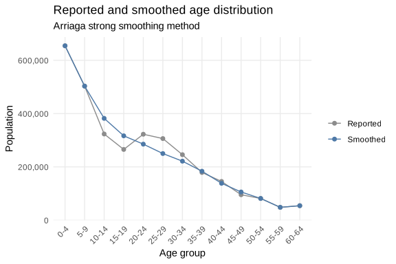

```r
plot(s)
```

`graduate()` then splits the smoothed groups into single years of age. With Sprague’s multipliers, the default, the single years of each group add back to that group exactly:

```r
g <- graduate(s$table, "age", "smoothed", graph = FALSE)
head(g$table)
```

```
#>   age population
#> 1   0   143539.1
#> 2   1   137178.1
#> 3   2   130813.9
#> 4   3   124487.5
#> 5   4   118239.4
#> 6   5   112110.4
```

```r
max(abs(g$groups$difference))
```

```
#> [1] 5.820766e-11
```

Single years can also be smoothed directly. `smooth_single_ages()` applies the weighted moving average of the Census Bureau’s POP1SM workbook, which removes the heaping on ages ending in 0 and 5 from the Ghana 2021 males:

```r
s1 <- smooth_single_ages(males, "Age", "Population", graph = FALSE)
c(Whipple_reported = s1$whipple_reported,
  Whipple_smoothed = s1$whipple_smoothed)
```

```
#> Whipple_reported Whipple_smoothed
#>        115.29238         99.85183
```

`smam()` computes the singulate mean age at marriage from proportions single by age. Preston et al. (2001, Box 4.4) report 25.0 years for Turkish males in 1990:

```r
turkey <- data.frame(
  age    = seq(15, 50, 5),
  men    = c(3165061, 2581153, 2435765, 2096899, 1784121, 1418784,
             1111113, 980115),
  single = c(3030203, 1853222, 629077, 180767, 77134, 43412, 28627, 22527)
)
smam(turkey, age = "age", single = "single", total = "men")$SMAM
```

```
#> [1] 24.98756
```

## 10. Figures

Core functions take `graph = TRUE`, attaching a **ggplot2** figure retrievable with `plot()`. A standalone `pyramid()` draws a population pyramid.

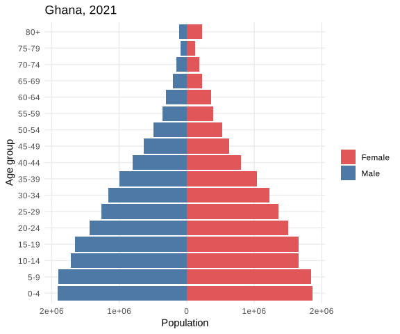

```r
g <- within(ghpop2021, grp <- ifelse(Age >= 80, "80+",
            paste0((Age %/% 5) * 5, "-", (Age %/% 5) * 5 + 4)))
pyr <- aggregate(Population ~ grp + Sex, data = g, FUN = sum)
pyramid(pyr, age_col = "grp", sex_col = "Sex", count_col = "Population",
        title = "Ghana, 2021")
```

## References

Coale, A. J., & Trussell, T. J. (1974). Model fertility schedules. *Population Index*, 40(2), 185–258.

Arriaga, E. E., Johnson, P. D., & Jamison, E. (1994). *Population Analysis with Microcomputers, Volume I: Presentation of Techniques*. Washington, DC: U.S. Bureau of the Census.

Carrier, N. H., & Farrag, A. M. (1959). The reduction of errors in census populations for statistically underdeveloped countries. *Population Studies*, 12(3), 240–285.

Hajnal, J. (1953). Age at marriage and proportions marrying. *Population Studies*, 7(2), 111–136.

Kpedekpo, G. M. K. (1982). *Essentials of Demographic Analysis for Africa*. London: Heinemann.

Preston, S. H., Heuveline, P., & Guillot, M. (2001). *Demography: Measuring and Modeling Population Processes*. Oxford: Blackwell.

Siegel, J. S., & Swanson, D. A. (Eds.) (2004). *The Methods and Materials of Demography* (2nd ed.). San Diego: Elsevier.

Sprague, T. B. (1880). Explanation of a new formula for interpolation. *Journal of the Institute of Actuaries*, 22(4), 270–285.

United Nations (1983). *Manual X: Indirect Techniques for Demographic Estimation*. New York: United Nations.